# Axis Insurance Project - Naeem Sufi

# Objective –

### Statistical Analysis of Business Data. Explore the dataset and extract insights from the data. The idea is for you to get comfortable with doing statistical analysis in Python.

### Import normal packages

##### Here are 4 essential packages used in this project

#### 1. Numpy

#### 2. Pandas

#### 3. Seaborn

#### 4. Matplotlib

```python
#import numpy of numerical python
import numpy as np
#import pandas for dealing with dataframe
import pandas as pd
#import seaborn and matplotlib for ploting the graphs
import seaborn as sns
import matplotlib.pyplot as plt
#setting the figure size to 12X9
sns.set(rc={'figure.figsize':(12,9)})
```

### Creating Dataframe from dataset

```python
#create instance called dataset of type pandas dataframe from csv file
dataset=pd.read_csv("AxisInsurance.csv")
```

### Display Data from Dataframe

```python
dataset
```

|  | age | sex | bmi | children | smoker | region | charges |
| --- | --- | --- | --- | --- | --- | --- | --- |
| 0 | 19 | female | 27.900 | 0 | yes | southwest | 16884.92400 |
| 1 | 18 | male | 33.770 | 1 | no | southeast | 1725.55230 |
| 2 | 28 | male | 33.000 | 3 | no | southeast | 4449.46200 |
| 3 | 33 | male | 22.705 | 0 | no | northwest | 21984.47061 |
| 4 | 32 | male | 28.880 | 0 | no | northwest | 3866.85520 |
| ... | ... | ... | ... | ... | ... | ... | ... |
| 1333 | 50 | male | 30.970 | 3 | no | northwest | 10600.54830 |
| 1334 | 18 | female | 31.920 | 0 | no | northeast | 2205.98080 |
| 1335 | 18 | female | 36.850 | 0 | no | southeast | 1629.83350 |
| 1336 | 21 | female | 25.800 | 0 | no | southwest | 2007.94500 |
| 1337 | 61 | female | 29.070 | 0 | yes | northwest | 29141.36030 |

1338 rows × 7 columns

### Looking at snapshot of dataset

```python
#used head() method to create snapshot of first five rows of the dataset
dataset.head()
```

|  | age | sex | bmi | children | smoker | region | charges |
| --- | --- | --- | --- | --- | --- | --- | --- |
| 0 | 19 | female | 27.900 | 0 | yes | southwest | 16884.92400 |
| 1 | 18 | male | 33.770 | 1 | no | southeast | 1725.55230 |
| 2 | 28 | male | 33.000 | 3 | no | southeast | 4449.46200 |
| 3 | 33 | male | 22.705 | 0 | no | northwest | 21984.47061 |
| 4 | 32 | male | 28.880 | 0 | no | northwest | 3866.85520 |

### Looking at the Tail of Dataset

```python
dataset.tail()
```

|  | age | sex | bmi | children | smoker | region | charges |
| --- | --- | --- | --- | --- | --- | --- | --- |
| 1333 | 50 | male | 30.97 | 3 | no | northwest | 10600.5483 |
| 1334 | 18 | female | 31.92 | 0 | no | northeast | 2205.9808 |
| 1335 | 18 | female | 36.85 | 0 | no | southeast | 1629.8335 |
| 1336 | 21 | female | 25.80 | 0 | no | southwest | 2007.9450 |
| 1337 | 61 | female | 29.07 | 0 | yes | northwest | 29141.3603 |

### How Many Columns and Rows are in Dataframe

```python
#how many rows and columns are there in dataframe
print("The data frame has {} rows and {} columns".format(dataset.shape[0],dataset.shape[1]))
```

```
The data frame has 1338 rows and 7 columns
```

### What is the Type of each Column

```python
dataset.dtypes
```

```
age           int64
sex          object
bmi         float64
children      int64
smoker       object
region       object
charges     float64
dtype: object
```

##### Age, BMI, Children, Cahrges columns have numeric datatype & SEX,SMOKER,REGION columns have object datatype

### Information of DataFrame

```python
dataset.info()
```

```
<class 'pandas.core.frame.DataFrame'>
RangeIndex: 1338 entries, 0 to 1337
Data columns (total 7 columns):
 #   Column    Non-Null Count  Dtype
---  ------    --------------  -----
 0   age       1338 non-null   int64
 1   sex       1338 non-null   object
 2   bmi       1338 non-null   float64
 3   children  1338 non-null   int64
 4   smoker    1338 non-null   object
 5   region    1338 non-null   object
 6   charges   1338 non-null   float64
dtypes: float64(2), int64(2), object(3)
memory usage: 73.3+ KB
```

### Are there any NULL values in the data ?

```python
dataset.apply(lambda x:sum(x.isnull()))
```

```
age         0
sex         0
bmi         0
children    0
smoker      0
region      0
charges     0
dtype: int64
```

##### From the above we can see there are no NULL values

### Size of the Datframe

```python
dataset.size
```

```
9366
```

### How many Males and Females

```python
dataset['sex'].value_counts()
```

```
male      676
female    662
Name: sex, dtype: int64
```

### How many children

```python
dataset['children'].value_counts()
```

```
0    574
1    324
2    240
3    157
4     25
5     18
Name: children, dtype: int64
```

# Exploratory Analysis

### AGE

#### Histogram and Boxplot for Age

1. It shows average age of an insurer
2. It shows the frequency of age for the insurers

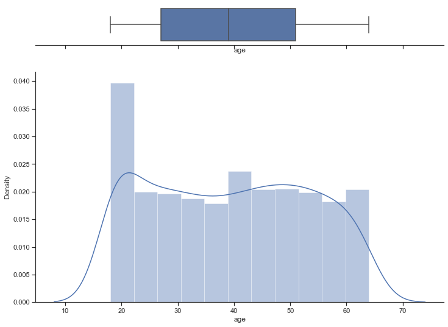

```python
#import warning to supress in out
import warnings
#supress warning
warnings.filterwarnings('ignore')
#set plot style
sns.set(style="ticks")
#set x equals to column of our interest which is age here
x=dataset['age']
#create figure f, boxplot and histogram in single chart
f, (ax_box, ax_hist) = plt.subplots(2, sharex=True,
                                    gridspec_kw={"height_ratios": (.15, .85)})
#set input in boxplot
sns.boxplot(x, ax=ax_box)
#set input in histogram
sns.distplot(x, ax=ax_hist)
ax_box.set(yticks=[])
#plot the histogram
sns.despine(ax=ax_hist)
#plot the  boxplot
sns.despine(ax=ax_box, left=True)
```

# Exploratory Analysis

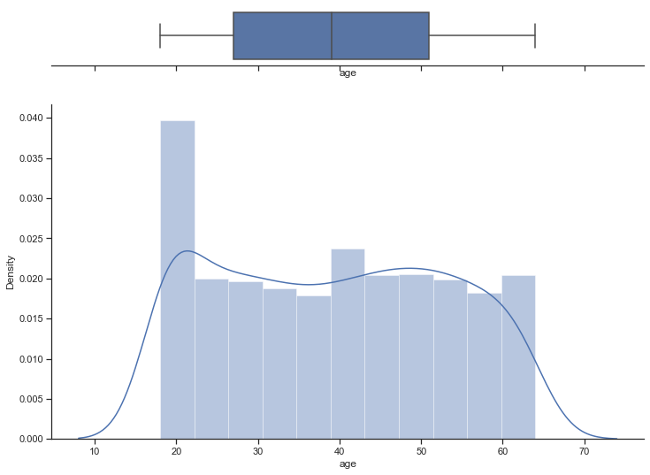

```python
#import warning to supress in out
import warnings
#supress warning
warnings.filterwarnings('ignore')
#set plot style
sns.set(style="ticks")
#set x equals to column of our interest which is BMI here
x=dataset['age']
#create figure f, boxplot and histogram in single chart
f, (ax_box, ax_hist) = plt.subplots(2, sharex=True,
                                    gridspec_kw={"height_ratios": (.15, .85)})
#set input in boxplot
sns.boxplot(x, ax=ax_box)
#set input in histogram
sns.distplot(x, ax=ax_hist)
ax_box.set(yticks=[])
#plot the histogram
sns.despine(ax=ax_hist)
#plot the  boxplot
sns.despine(ax=ax_box, left=True)
```

# Exploratory Analysis

### Children

#### Histogram and Boxplot for children

1. It shows average children of an insurer
2. It shows the frequency of children for the insurers

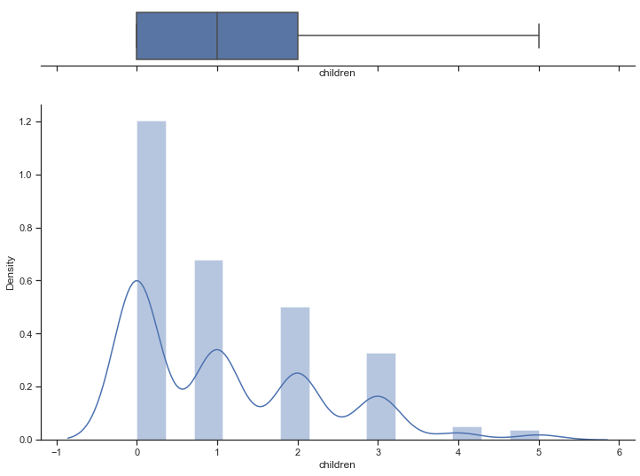

```python
#import warning to supress in out
import warnings
#supress warning
warnings.filterwarnings('ignore')
#set plot style
sns.set(style="ticks")
#set x equals to column of our interest which is children here
x=dataset['children']
#create figure f, boxplot and histogram in single chart
f, (ax_box, ax_hist) = plt.subplots(2, sharex=True,
                                    gridspec_kw={"height_ratios": (.15, .85)})
#set input in boxplot
sns.boxplot(x, ax=ax_box)
#set input in histogram
sns.distplot(x, ax=ax_hist)
ax_box.set(yticks=[])
#plot the histogram
sns.despine(ax=ax_hist)
#plot the  boxplot
sns.despine(ax=ax_box, left=True)
```

# Exploratory Analysis

### Charges

#### Histogram and Boxplot for charges

1. It shows average charges of an insurer
2. It shows the frequency of charges for the insurers

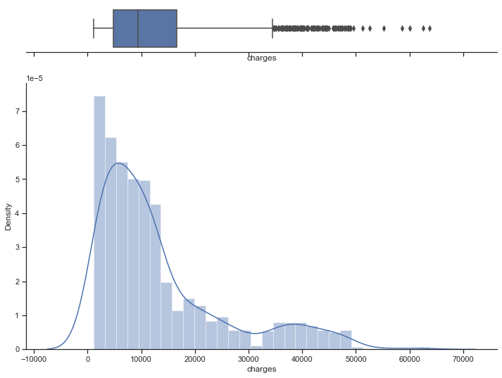

```python
#import warning to supress in out
import warnings
#supress warning
warnings.filterwarnings('ignore')
#set plot style
sns.set(style="ticks")
#set x equals to column of our interest which is charges here
x=dataset['charges']
#create figure f, boxplot and histogram in single chart
f, (ax_box, ax_hist) = plt.subplots(2, sharex=True,
                                    gridspec_kw={"height_ratios": (.15, .85)})
#set input in boxplot
sns.boxplot(x, ax=ax_box)
#set input in histogram
sns.distplot(x, ax=ax_hist)
ax_box.set(yticks=[])
#plot the histogram
sns.despine(ax=ax_hist)
#plot the  boxplot
sns.despine(ax=ax_box, left=True)
```

# Exploratory Analysis

### Sex

#### Bar chart

1. It shows the % of each gender served by axis insurance

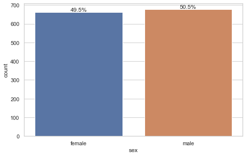

```python
#set chart style
sns.set(style="whitegrid")
#create figure from plt
plt.figure(figsize=(8,5))
#get the size of dataset
total = float(len(dataset))
#create chart ax with column sex and datasource equals to dataset
ax = sns.countplot(x="sex", data=dataset)
#calculate the percentage and put it on the top of bars with below code
for p in ax.patches:
    #how the percentage should be formated
    percentage = '{:.1f}%'.format(100 * p.get_height()/total)
    # % position in X
    x = p.get_x() + 0.4
    # % position in Y
    y = p.get_height()+5
    #put percentage on chart
    ax.annotate(percentage, (x, y),ha='center')
#plot the chart
plt.show()
```

# Exploratory Analysis

### Smoker

#### Bar chart

1. It shows the % of smokers and non smokers served by axis insurance

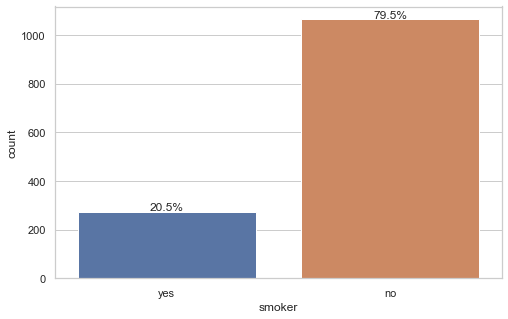

```python
#set chart style
sns.set(style="whitegrid")
#create figure from plt
plt.figure(figsize=(8,5))
#get the size of dataset
total = float(len(dataset))
#create chart ax with column sex and datasource equals to dataset
ax = sns.countplot(x="smoker", data=dataset)
#calculate the percentage and put it on the top of bars with below code
for p in ax.patches:
    #how the percentage should be formated
    percentage = '{:.1f}%'.format(100 * p.get_height()/total)
    # % position in X
    x = p.get_x() + 0.4
    # % position in Y
    y = p.get_height()+5
    #put percentage on chart
    ax.annotate(percentage, (x, y),ha='center')
#plot the chart
plt.show()
```

# Exploratory Analysis

### Region

#### Bar chart

1. It shows the % of customers served by axis insurance in each of the regions

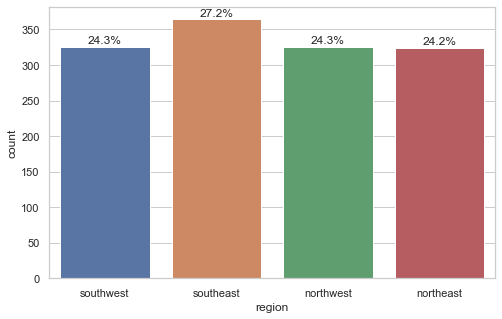

```python
#set chart style
sns.set(style="whitegrid")
#create figure from plt
plt.figure(figsize=(8,5))
#get the size of dataset
total = float(len(dataset))
#create chart ax with column sex and datasource equals to dataset
ax = sns.countplot(x="region", data=dataset)
#calculate the percentage and put it on the top of bars with below code
for p in ax.patches:
    #how the percentage should be formated
    percentage = '{:.1f}%'.format(100 * p.get_height()/total)
    # % position in X
    x = p.get_x() + 0.4
    # % position in Y
    y = p.get_height()+5
    #put percentage on chart
    ax.annotate(percentage, (x, y),ha='center')
#plot the chart
plt.show()
```

# Exploratory Analysis

### Children

#### Bar chart

1. It shows the % of children customer of axis insurance have

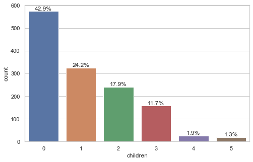

```python
#set chart style
sns.set(style="whitegrid")
#create figure from plt
plt.figure(figsize=(8,5))
#get the size of dataset
total = float(len(dataset))
#create chart ax with column sex and datasource equals to dataset
ax = sns.countplot(x="children", data=dataset)
#calculate the percentage and put it on the top of bars with below code
for p in ax.patches:
    #how the percentage should be formated
    percentage = '{:.1f}%'.format(100 * p.get_height()/total)
    # % position in X
    x = p.get_x() + 0.4
    # % position in Y
    y = p.get_height()+5
    #put percentage on chart
    ax.annotate(percentage, (x, y),ha='center')
#plot the chart
plt.show()
```

## Distribution of BMI

#### This chart shows the distribution of bmi in term of frequencey of BMI in a certain range

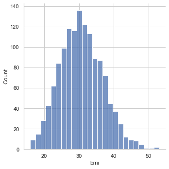

```python
#BMI is ploted
sns.displot(dataset, x="bmi")
```

# Exploratory Analysis

### Complete Dataset

#### Correlation matrix

1. It shows the correlation of each of feature on one another

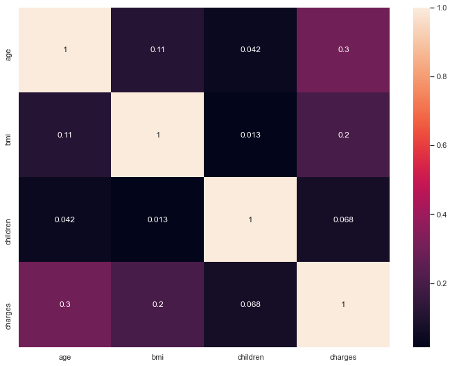

```python
#create a correlation chart from dataset annot is true because it put values in each square
sns.heatmap(dataset.corr(),annot = True)
```

## Skewness for each of the column

#### Skewness is the measure of the asymmetry of an ideally symmetric probability distribution and is given by the third standardized moment.

```python
from scipy.stats import skew
skew(dataset[['charges','age','bmi','children']])
```

```
array([1.51417971, 0.05561008, 0.28372857, 0.93732812])
```

# Exploratory Analysis

## bmi boxplot

#### In order to check for outlier boxplot for BMI is created. Dots on right side of graph show the outliers in BMI

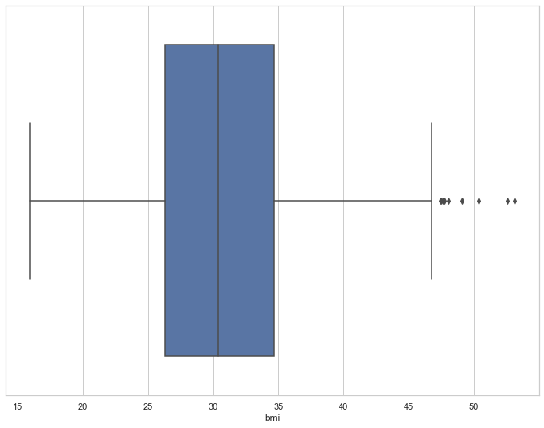

```python
sns.boxplot(x='bmi',data=dataset)
```

# Exploratory Analysis

## Age boxplot

#### In order to check for outlier in age boxplot for Age is created. There doesn't seem to have any outliers

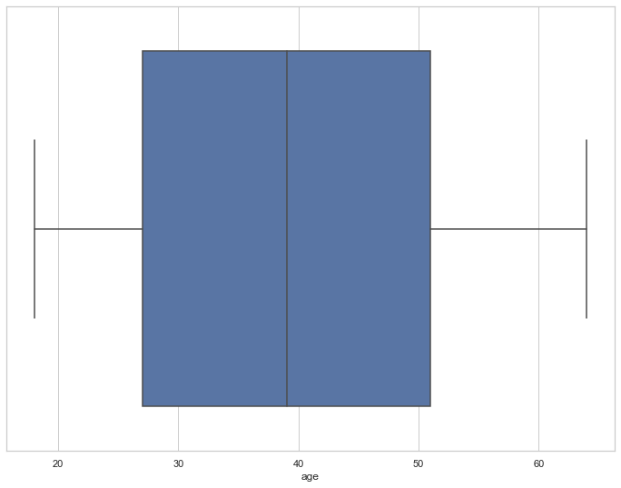

```python
sns.boxplot(x='age',data=dataset)
```

# Exploratory Analysis

## Charges boxplot

#### In order to check for outlier boxplot for charges is created. Dots on right side of graph show the outliers in charges

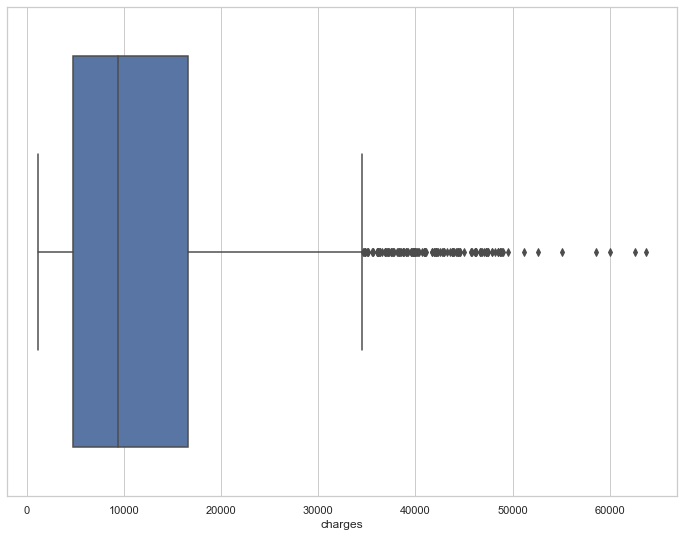

```python
sns.boxplot(x='charges',data=dataset)
```

# Exploratory Analysis

### Children VS BMI

#### Boxplot for Children VS BMI

1. It shows the relationship of number of children on BMI of an insurer
2. It shows the range of BMI values of customer with different number of children
3. It shows any outliers if exist between the relation of Children and BMI

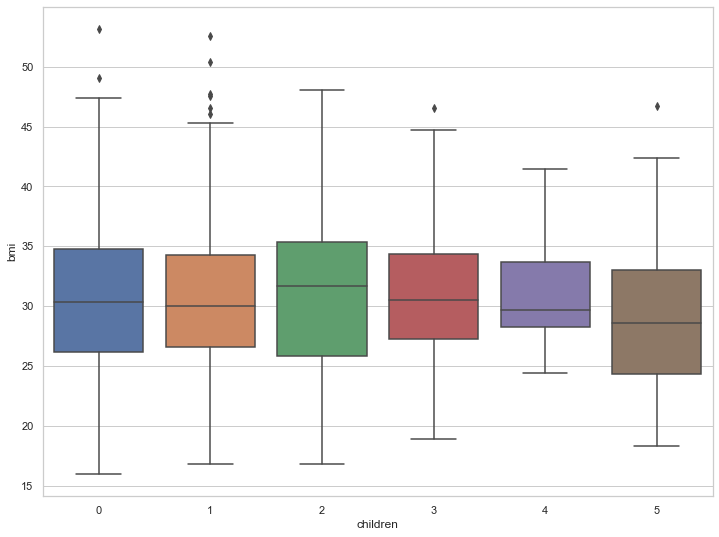

```python
#creating box plot for children vs bmi from dataset
ax = sns.boxplot(x="children", y="bmi", data=dataset)
```

# Exploratory Analysis

### Sex VS BMI

#### Boxplot for Sex VS BMI

1. It shows the relationship of Gender on BMI of an insurer
2. It shows the range of BMI values of customer for different genders
3. It shows any outliers if exist between the relation of Sex and BMI

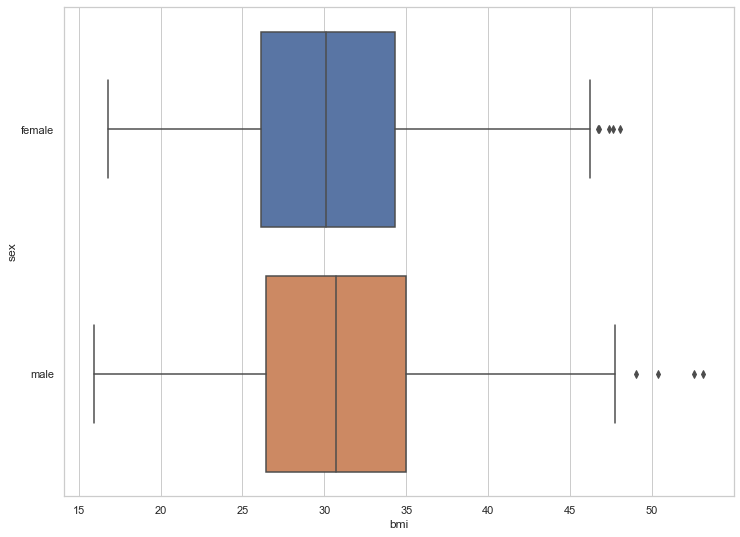

```python
#creating box plot for sex vs bmi from dataset. orient = h so graphs can be created horizontally
ax = sns.boxplot(x="bmi", y="sex", orient="h", data=dataset)
```

# Exploratory Analysis

### Children VS BMI VS Sex

#### Boxplot for Children VS BMI

1. It shows the relationship of number of children on BMI of an insurer of different gender
2. It shows the range of BMI values of customer with different number of children having different gender
3. It shows any outliers if exist between the relation of Children and BMI and Gender

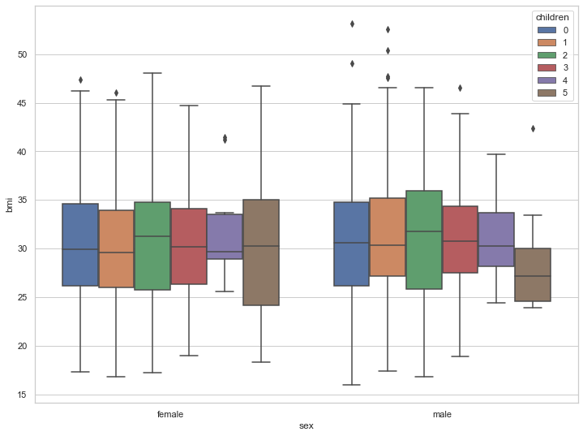

```python
#creating box plot for children vs bmi vs sex from dataset
ax = sns.boxplot(x="sex", y="bmi",hue='children', data=dataset)
```

# Exploratory Analysis

### Region VS Charges VS Smoker

#### Boxplot for Region VS Charges VS Smoker

1. It shows the relationship of charges with region and smoking habit of a insurer
2. It shows the range of Charge values of customer with different region and smoking habit

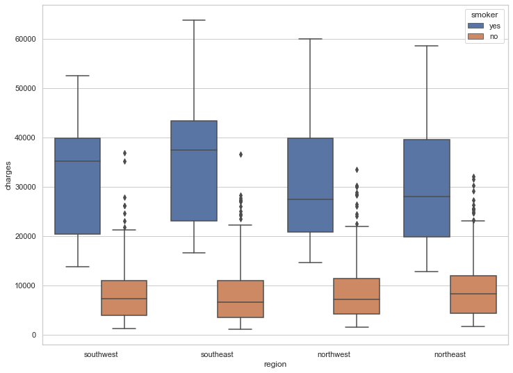

```python
#creating box plot for region vs charges vs smoker from dataset
ax = sns.boxplot(x="region", y="charges",hue='smoker', data=dataset)
```

# Exploratory Analysis

1. It shows the relationship of charges with BMI and Gender of a insurer

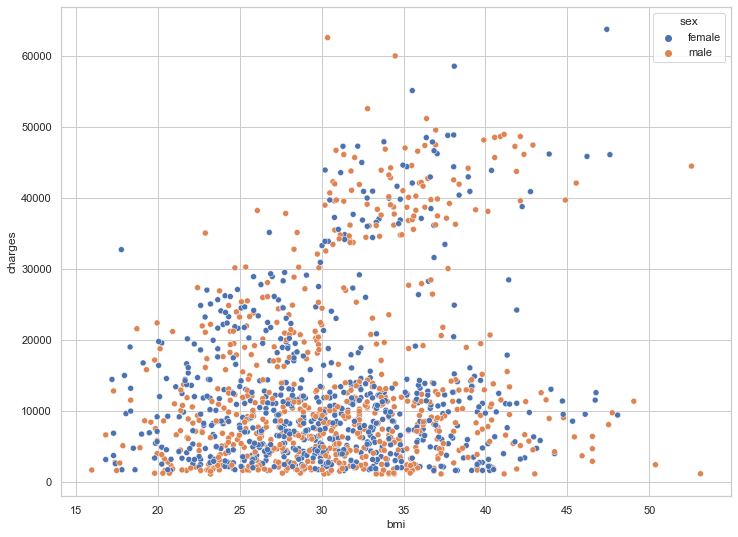

```python
#creating scatter plot for charges vs bmi vs sex from dataset
ax = sns.scatterplot(x="bmi", y="charges",hue='sex', data=dataset)
```

# Exploratory Analysis

### pairplot with smoker as hue

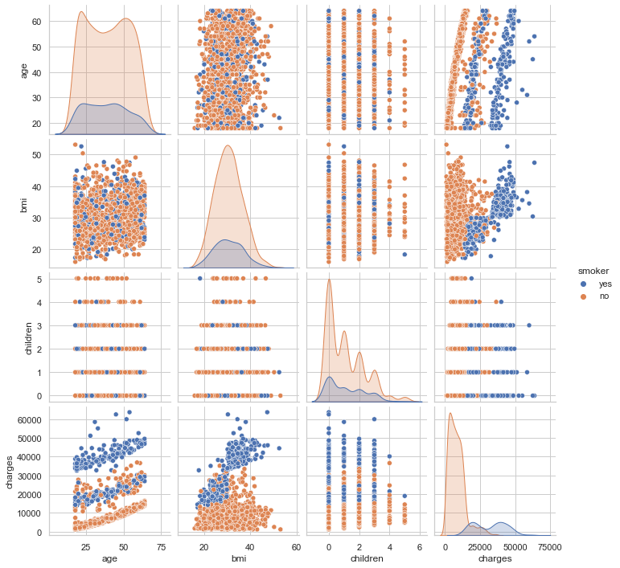

```python
sns.pairplot(dataset, hue="smoker")
```

# Exploratory Analysis

### pairplot with sex as hue

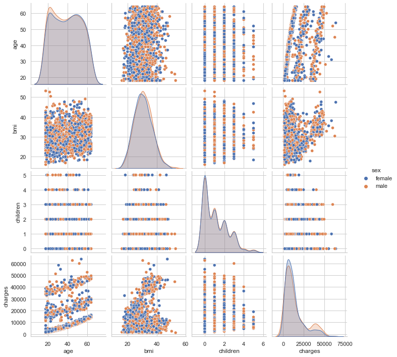

```python
sns.pairplot(dataset, hue="sex")
```

# Exploratory Analysis

### pairplot with region as hue

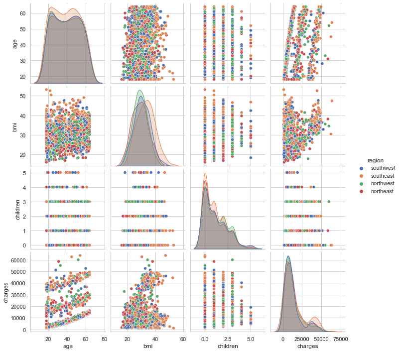

```python
sns.pairplot(dataset, hue="region")
```

# Statistical Analysis

### Prove (or disprove) that the medical claims made by the people who smoke is greater than those who don't?

#### Null Hypothesis--> H0 = "charges has no effect on smoking"

#### Alternate hypothesis--> H1 = "charges has effect on smoking"

```
32050.23183153285
8434.268297856199
Ttest_indResult(statistic=46.664921172723716, pvalue=8.271435842177219e-283)
```

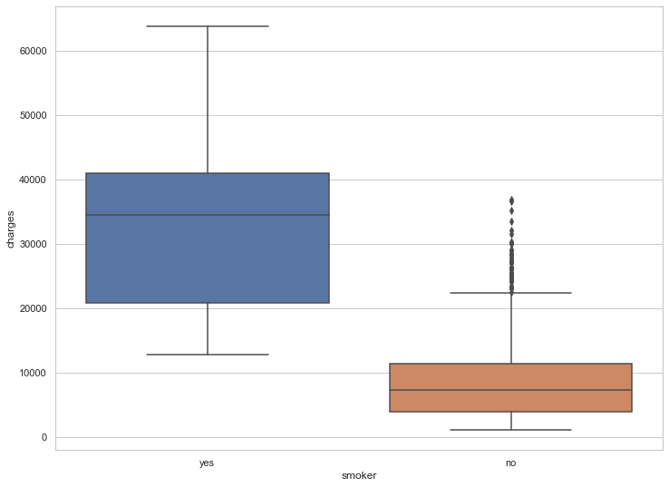

```python
#code performs the T-Test
#import independent t test
from scipy.stats import ttest_ind
#create category of smokers
cat1 = dataset[dataset['smoker']=='yes']
#create category of non smokers
cat2 = dataset[dataset['smoker']=='no']
#mean claims by smokers
print(cat1['charges'].mean())
#mean claims by non-smokers
print(cat2['charges'].mean())
#apply independent t test
print(ttest_ind(cat1['charges'], cat2['charges']))
#plot smoker vs charges
ax = sns.boxplot(x="smoker", y="charges", data=dataset)
```

# Statistical Analysis

#### Alternate hypothesis--> H1 = "Gender has effect on BMI"

```
Ttest_indResult(statistic=0.974043464681153, pvalue=0.330170504024037)
```

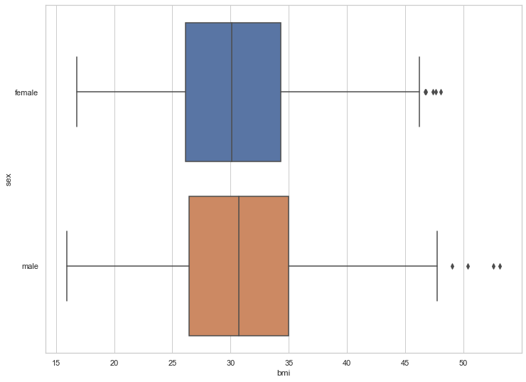

```python
#code performs the T-Test
#import independent t test
from scipy.stats import ttest_ind
#create category of male
cat1 = dataset[dataset['sex']=='male']
#create category of female
cat2 = dataset[dataset['smoker']=='no']
#apply independent t test
print(ttest_ind(cat1['bmi'], cat2['bmi']))
#plot bmi vs sex
ax = sns.boxplot(x="bmi", y="sex", orient="h", data=dataset)
```

## Is the proportion of smokers significantly different across different regions?

#### Null Hypothesis--> H0 = "Smokers are effected by region"

#### Alternate hypothesis--> H1 = "Smokers are not effected by region"

```
(7.34347776140707, 0.06171954839170547, 3, array([[257.65022422, 258.44544096, 289.45889387, 258.44544096],
       [ 66.34977578,  66.55455904,  74.54110613,  66.55455904]]))
```

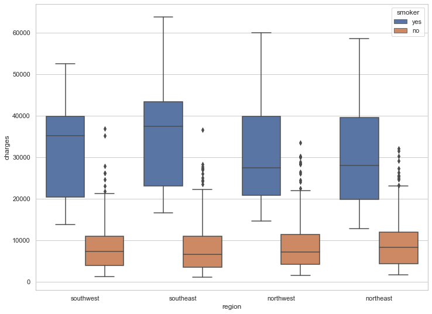

```python
from scipy.stats import chi2_contingency
data_crosstab = pd.crosstab(dataset['smoker'],
                            dataset['region'],
                               margins = False)
print(chi2_contingency(data_crosstab))
ax = sns.boxplot(x="region", y="charges", hue='smoker',data=dataset)
```

#### Alternate hypothesis--> H1 = ""Average BMI of female with 0,1,2 children is not same""

```
(0.0, 1.0, 0, array([[574., 324., 240.]]))
```

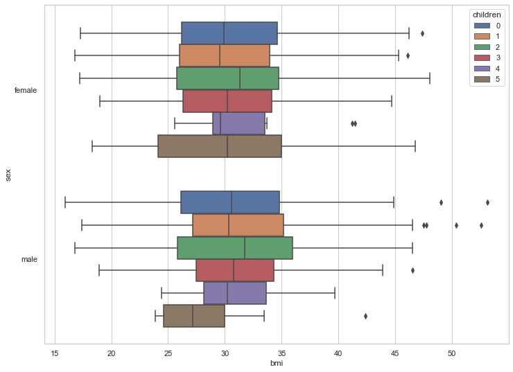

```python
from scipy.stats import chi2_contingency
data_crosstab = pd.crosstab(dataset[dataset['sex']=='female']['bmi'].mean,
                            dataset['children'],
                               margins = False)
print(chi2_contingency(data_crosstab.iloc[:,0:3]))
ax = sns.boxplot(x="bmi", y="sex", hue='children', data=dataset)
```